# Data science per psicologi - demo 18.01

Corrado Caudek

2022-04-07

```r
suppressPackageStartupMessages({
  library("here")
  library("tidyverse")
  library("bayesplot")
})

theme_set(bayesplot::theme_default(base_size = 12))
bayesplot::color_scheme_set("gray")
set.seed(84735)

knitr::opts_chunk$set(
  collapse = TRUE,
  tidy = 'styler',
  fig.width = 6,
  fig.asp = 0.618 # 1 / phi
)
```

# Campionamento MCMC mediante l’algoritmo di Metropolis

Usiamo l’algoritmo di Metropolis per generare un campione casuale estratto dalla distribuzione a posteriori. Consideriamo qui il caso beta-binomiale di cui conosciamo la soluzione. Supponiamo che i dati corrispondano a 23 successi in 30 prove Bernoulliane indipendenti, tutte con probabilità di successo uguale a $\theta$ incognito. Supponiamo inoltre che le nostre credenze a priori su $\theta$ possano essere descritte da una $\mbox{Beta}(2, 10)$.

In tali circostanze sappiamo che la distribuzione a posteriori sarà una $\mbox{Beta}(2 + 23, 10 + 30 - 23)$.

```r
bayesrules:::summarize_beta_binomial(
  alpha = 2, beta = 10, y = 23, n = 30
)
```

```
##       model alpha beta      mean mode         var        sd
## 1     prior     2   10 0.1666667  0.1 0.010683761 0.1033623
## 2 posterior    25   17 0.5952381  0.6 0.005603016 0.0748533
```

Vogliamo ottenere questo risultato usando un campionamento MCMC mediante l’algoritmo di Metropolis.

## Funzioni utilizzate

L’algoritmo di Metropolis richiede l’uso delle seguenti funzioni.

### Verosimiglianza

La verosimiglianza del modello binomiale.

```r
likelihood <- function(param, x = 23, N = 30) {
  dbinom(x, N, param)
}
```

### Distribuzione a priori

La distribuzione a priori è una $\mbox{Beta}(2, 10)$.

```r
prior <- function(param, alpha = 2, beta = 10) {
  dbeta(param, alpha, beta)
}
```

### Distribuzione a posteriori

La distribuzione a posteriori è data dal prodotto della distribuzione a priori e della verosimiglianza.

```r
posterior <- function(param) {
  likelihood(param) * prior(param)
}
```

### Valore proposto

L’algoritmo di Metropolis produce una sequenza di valori (chiamata ‘catena di Markov’) nella quale ciascun valore successivo della catena viene trovato utilizzando solamente le informazioni fornite dal valore precedente della catena. Ad ogni passo della catena, sulla base delle informazioni fornite dal valore corrente, selezioniamo un valore ‘candidato’. In base ad una certa regola, decidiamo poi se accettare il valore candidato, e muovere la catena al nuovo valore, oppure se rifiutarlo, ripetendo, nel passo successivo della catena, il valore corrente. Ci fermiamo dopo una serie predefinita di passi.

La funzione seguente produce il valore ‘candidato’.

```r
proposal_distribution <- function(param) {
  # creo la condizione che forza l'entrata nel ciclo while()
  res <- -1
  # resto all'interno del ciclo finché res è minore di 0 o maggiore di 1
  while (res < 0 | res > 1) {
    # quando res è un numero in [0, 1] viene falsificata la condizione
    # del ciclo while() e si esce dal ciclo
    res <- rnorm(1, mean = param, sd = 0.9)
  }
  # res è dunque un numero a caso, compreso tra 0 e 1, estratto da una gaussiana
  # con media uguale al valore param e deviazione standard 0.9 -- il che
  # significa che ritornerà valori molto simili a param (un po' più piccoli o
  # un po' più grandi)
  res
}
```

## L’algoritmo di Metropopolis

Ricordiamo che, nel caso particolare di questo esempio, la distribuzione a posteriori avrà un supporto nell’intervallo [0, 1]. Il primo punto della catena sarà dunque un valore a caso tra 0 e 1.

```r
startvalue <- runif(1, 0, 1)
```

La catena di Markov viene generata utilizzando l’algoritmo di Metropolis che può essere impliementato nella seguente funzione.

La funzione ha come argomenti il valore iniziale e il numero di passi della catena.

```r
metropolis <- function(startvalue, iterations) {
  # Creo un contenitore vuoto dove salvare i risultati.
  chain <- vector(length = iterations + 1)
  # Inizializzo la catena con startvalue.
  chain[1] <- startvalue
  # Ripeto le istruzioni seguenti un numero di volte pari a iterations.
  for (i in 1:iterations) {
    # Ottengo un valore a caso molto simile al valore corrente della catena.
    proposal <- proposal_distribution(chain[i])
    # Calcolo il rapporto tra la densità a posteriori del valore proposto e
    # la densità a posteriori del valore corrente.
    prob_move <- posterior(proposal) / posterior(chain[i])
    # Se la densità a posteriori del valore proposto è maggiore di quella del
    # valore corrente, allora accetto la proposta: la catena si muove dal valore
    # corrente al valore proposto (che diventa il valore corrente della
    # seguente iterazione). Altrimenti il valore proposto viene accettato solo
    # in una proporzione di casi uguale al rapporto tra densità a posteriori
    # del valore proposto e la densità a posteriori del valore corrente.
    if (prob_move > 1) {
      chain[i + 1] <- proposal
    } else {
      r <- runif(1, 0, 1)
      chain[i + 1] <- ifelse(r < prob_move, proposal, chain[i])
    }
  }
  # Ritorno i valori della catena.
  chain
}
```

```r
prob <- 0.3
nrep <- 1e4
sim <- rep(NA, nrep)
for (i in 1:nrep) {
  r <- runif(1, 0, 1)
  sim[i] <- ifelse(r < prob, 1, 0)
}
mean(sim)
```

```
## [1] 0.3012
```

Si accetta il valore proposto di $\theta$ con una probabilità uguale a `prob_move`. Di conseguenza, la frequenza dei valori nella catena sarà proporzionale alla densità della distribuzione a posteriori.

## Implemento l’algoritmo di Metropolis

```r
set.seed(84735)
startvalue <- runif(1, 0, 1)
niter <- 1e5
chain <- metropolis(startvalue, niter)
```

### Accettanza

Calcolo l’accettanza.

```r
burnin <- niter / 2
acceptance <- 1 - mean(duplicated(chain[-(1:burnin)]))
acceptance
```

```
## [1] 0.2534149
```

### Descrizione dell’approssimazione alla distribuzione a posteriori

Calcolo la media dell’approssimazione numerica della distribuzione a posteriori.

```r
mean(chain[-(1:burnin)])
```

```
## [1] 0.5940539
```

Calcolo la deviazione standard dell’approssimazione numerica della distribuzione a posteriori.

```r
sd(chain[-(1:burnin)])
```

```
## [1] 0.07487919
```

Confronto i risultati ottenuti con l’algoritmo di Metropolis con quelli ottenuti per via analitica.

```r
bayesrules:::summarize_beta_binomial(
  alpha = 2, beta = 10, y = 23, n = 30
)
```

```
##       model alpha beta      mean mode         var        sd
## 1     prior     2   10 0.1666667  0.1 0.010683761 0.1033623
## 2 posterior    25   17 0.5952381  0.6 0.005603016 0.0748533
```

Creo un kernel density plot per la distribuzione a posteriori.

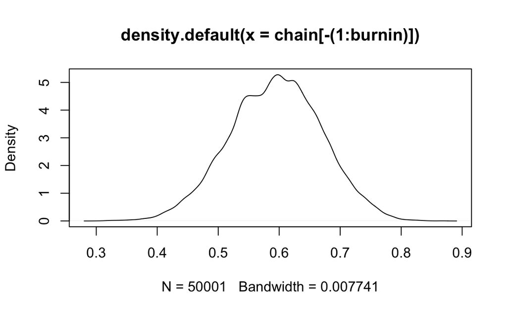

```r
plot(density(chain[-(1:burnin)]))
```

La distribuzione a posteriori è una Beta(25, 17). La figura seguente rappresenta un istogramma dei valori $\theta$ prodotti dall’algoritmo di Metropolis a cui è stata sovrapposta la distribuzione a posteriori ottenuta per via analitica, ovvero una Beta(25, 17).

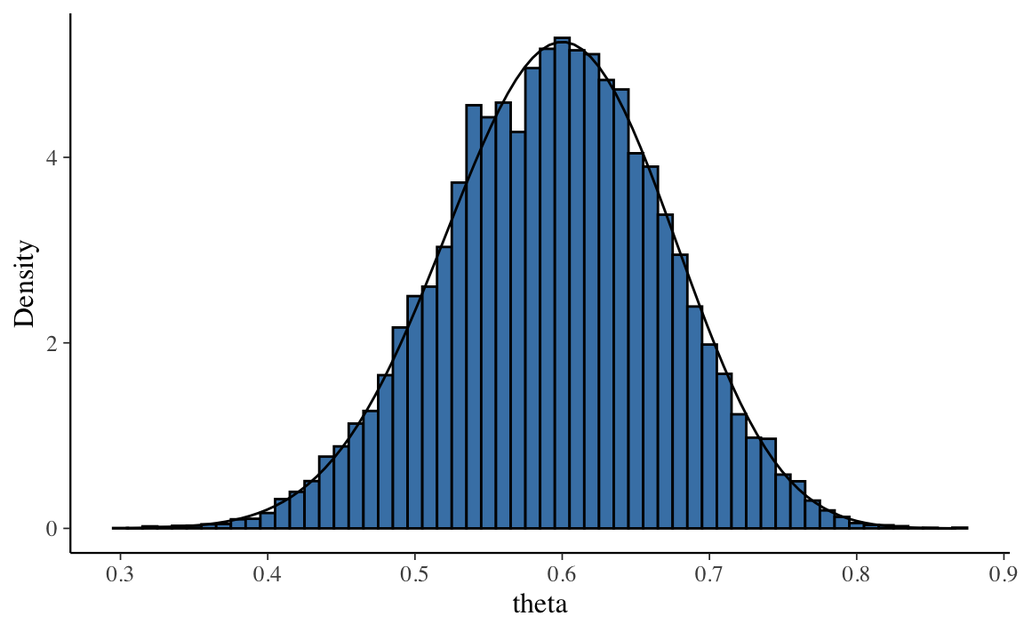

```r
df <- tibble(x = chain[-(1:burnin)])

df %>%
  ggplot(aes(x = x)) +
  geom_histogram(
    mapping = aes(x = x, y = ..density..),
    fill = "steelblue",
    colour = "black",
    binwidth = 0.01
  ) +
  stat_function(fun = dbeta, args = list(shape1 = 25, shape2 = 17)) +
  labs(
    x = "theta",
    y = "Density"
  )
```

Si vede che la catena converge alla corretta distribuzione a posteriori.

## Versione 2

È equivalente scrivere l’algoritmo di Metropolis nel modo seguente.

```r
startvalue <- runif(1, 0, 1)
metropolis <- function(startvalue, iterations) {
  chain <- vector(length = iterations + 1)
  chain[1] <- startvalue
  for (i in 1:iterations) {
    proposal <- proposal_distribution(chain[i])
    prob_move <- posterior(proposal) / posterior(chain[i])
    chain[i + 1] <-
      ifelse(runif(1) < prob_move, proposal, chain[i])
  }
  chain
}
```

```r
set.seed(84735)
startvalue <- runif(1, 0, 1)
niter <- 1e5
chain <- metropolis(startvalue, niter)

burnin <- niter / 2
acceptance <- 1 - mean(duplicated(chain[-(1:burnin)]))
acceptance
```

```
## [1] 0.251435
```

```r
mean(chain[-(1:burnin)])
```

```
## [1] 0.5932765
```

```r
sd(chain[-(1:burnin)])
```

```
## [1] 0.07417964
```